# Final Exam

STAT 353

Shanshui Gu

# An Overview of the Problem

In the United States, gun violence in K-12 schools has grown rapidly over the past two decades. For example, the mass shooting at Uvalde Elementary in Texas (2022) received a large degree of media attention. While the scale of this event was extreme, however, gun violence of smaller scales is more [common](https://news.google.com/search?q=gun%20school&hl=en-US&gl=US&ceid=US%3Aen) .

As gun violence increases, researchers and policymakers continue to search for solutions. These include ideas like increasing monitoring of social and mental health of students, using metal detectors, stationing police in schools, among others. This question - What can we do to reduce gun violence? - provides the background for this exam.

## The SSOCS Data

“The School Survey on Crime and Safety (SSOCS) — a nationally representative survey of U.S. K–12 public schools — is managed by the National Center for Education Statistics (NCES), an agency within the U.S. Department of Education’s Institute of Education Sciences. SSOCS collects detailed information from public schools on the incidence, frequency, seriousness, and nature of violence affecting students and school personnel. SSOCS also collects information on the programs, practices, and policies that schools have in place to prevent and reduce crime. Data from this collection can be used to examine the relationship between school characteristics and violent crimes in regular public primary, middle, high, and combined schools.”

All of the information that you need to understand this data is provided. This includes:

- `SSOCS(2017-2018)Data.csv` : The data
- `ssocs codebook.pdf` : The code book

Notice that in the code book, the `Appendix A` includes the actual survey and that `Appendix B` includes a list of all the variable names and definitions. Further information on the creation of composite variables (those ending in “18”) can be found in `Chapter 5`.

(Throughout, pay particular attention to data with values of “-1”. These are purposeful skips and in many (but not all) cases may need to be re-coded to “0”.)

## This Exam

The purpose of this exam is to test your ability to put to use all that you have learned in STAT 353 in the context of real data, with a real question. This involves combining your understanding of regression concepts and theory with the implementation of these in code and clear interpretation to a lay audience. Be sure to convey what the results tell you, what assumptions they require, and any limitations in your results.

For this exam, we will focus in particular on two outcomes:

- `INCID18` : total incidents of any crime
- `DISFIRE18` : total use of firearm or explosive

To simply the analysis, you can ignore the sampling weights / jackknife replicates.

**Finally, a strong exam is one that is judicious in what is presented (you can put materials in an Appendix), that explains the decisions and assumptions that were made and why, that explains the how the results should be interpreted, and that is clear in any limitations.**

# Part I. Testing Hypotheses

As stated above, researchers and policymakers have hypothesized and enacted a variety of policies meant to reduce crimes and gun violence in schools. In particular, they often argue that schools should include *security guards* in order to reduce crime and gun violence.

For this part, answer the following questions:

1. After exploring the two outcomes (`INCID18` and `DISFIRE18`) determine what type of regression model is appropriate for each (e.g., OLS). Explain which is best and why.

Firstly, I check the basic statistics of the data and density plot.

```
##    Min. 1st Qu.  Median    Mean 3rd Qu.    Max.
##     0.0     5.0    15.0    28.2    35.0   376.0
```

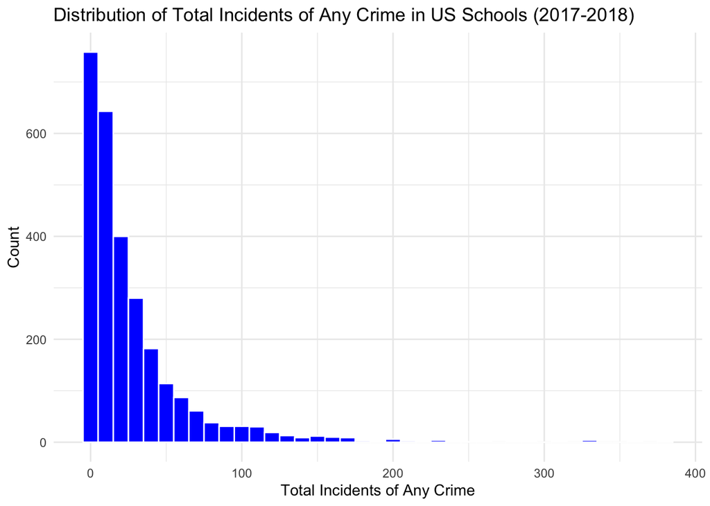

```
##     Min.  1st Qu.   Median     Mean  3rd Qu.     Max.
##  0.00000  0.00000  0.00000  0.09848  0.00000 81.00000
```

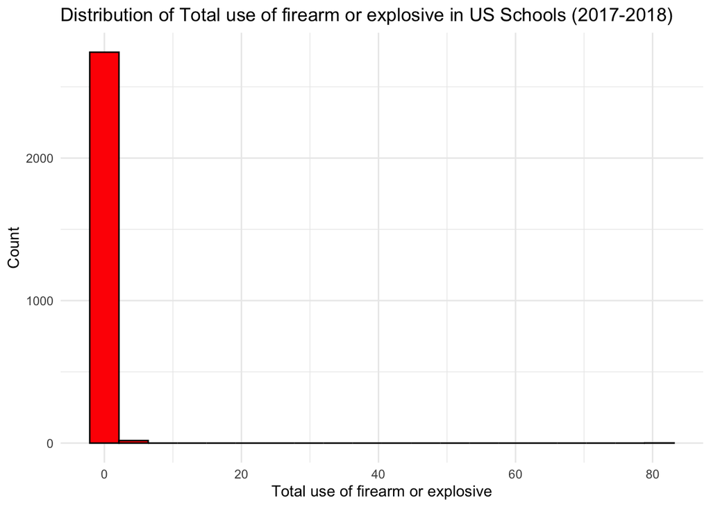

The histogram illustrates that there is a right-skewed distribution of incidents in the `INCID18` variable, with a small number of schools experiencing a high number of incidents, while the majority of schools experience a relatively low number. This implies that an OLS regression model may not be the most suitable fit for this data as it assumes a normally distribution. Instead, it might be more appropriate to use Poisson regression or Negative Binomial regression to model the count of incidents. It’s necessary to test for overdispersion to determine whether the use of NB regression is necessary. But for Poisson regression, we need to assume the mean and variance are equal, which seems unrealistic in this scenario. To verify this, we can firstly use Poisson distribution in GLM framework and compare it to the Negative binomial regression.

`DISFIRE18` denotes the total use of firearm or explosive, which consists of negative values. I used a transformation method to get rid of these issues and make it appropriate to fit in both Poisson and Negative binomial regression. According to the output, `DISFIRE18` variable is skewed and contains a few outliers. In addition, the variable has a limited number of distinct values (0, 1, 2, 3, 4, 5, 6, 81), which suggests that a linear regression model may not be appropriate for this variable. Thus, a more suitable model for `DISFIRE18` may be a Poisson regression model or NB regression. I also noticed the variability of the counts were larger for the variables. It would appear that the negative binomial distribution would better approximate the distribution of the counts. Likewise, further information is required to test for over-dispersion.

2. Are the presence of *security guards* (`SEC_FT18` and `SEC_PT18`) associated with reductions in crime (`INCID18`) and gun violence (`DISFIRE18`)? Interpret the effects clearly in language that a non-statistician could understand.

```
##              INCID18    DISFIRE18    SEC_FT18     SEC_PT18
## INCID18   1.00000000  0.046285435 0.160887166  0.045172009
## DISFIRE18 0.04628544  1.000000000 0.009553505 -0.007261662
## SEC_FT18  0.16088717  0.009553505 1.000000000  0.058271818
## SEC_PT18  0.04517201 -0.007261662 0.058271818  1.000000000
```

```
## [1] -0.01050755
```

```
## [1] 0.03215923
```

Next, we are conducting diagnostic checks for outliers and influential points.

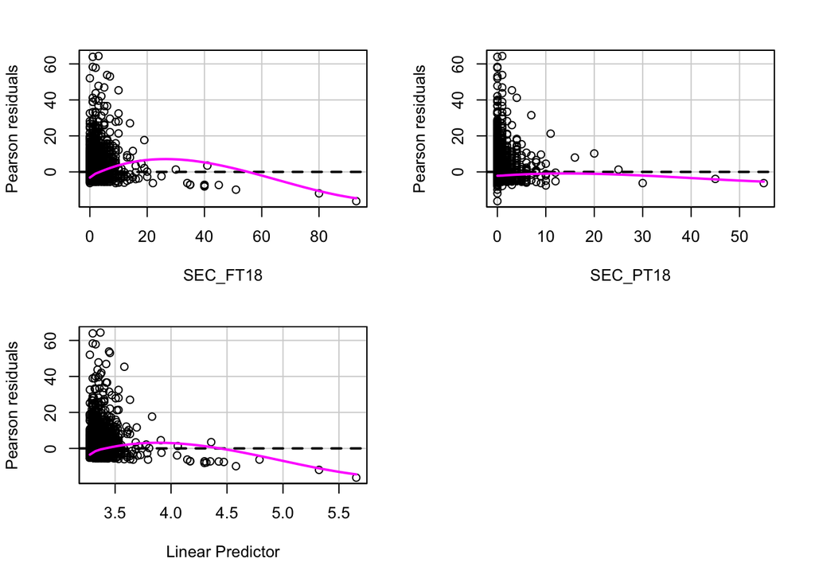

```
##          Test stat Pr(>|Test stat|)
## SEC_FT18   8963.41        < 2.2e-16 ***
## SEC_PT18    224.04        < 2.2e-16 ***
## ---
## Signif. codes:  0 '***' 0.001 '**' 0.01 '*' 0.05 '.' 0.1 ' ' 1
```

```
##      rstudent unadjusted p-value Bonferroni p
## 338  35.11753        3.6405e-270  1.0055e-266
## 72   34.60474        2.1443e-262  5.9225e-259
## 2690 32.39844        2.8870e-230  7.9739e-227
## 1065 32.31133        4.8494e-229  1.3394e-225
## 1453 31.16834        2.8624e-213  7.9058e-210
## 1455 30.86413        3.6204e-209  9.9995e-206
## 995  29.70296        7.0315e-194  1.9421e-190
## 1064 28.19383        6.9602e-175  1.9224e-171
## 190  28.05237        3.7375e-173  1.0323e-169
## 1840 27.94363        7.8781e-172  2.1759e-168
```

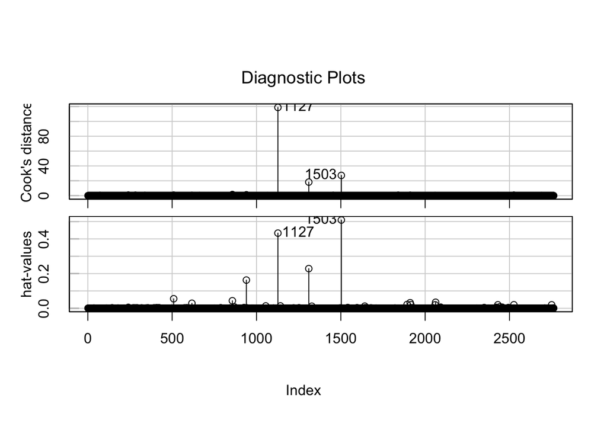

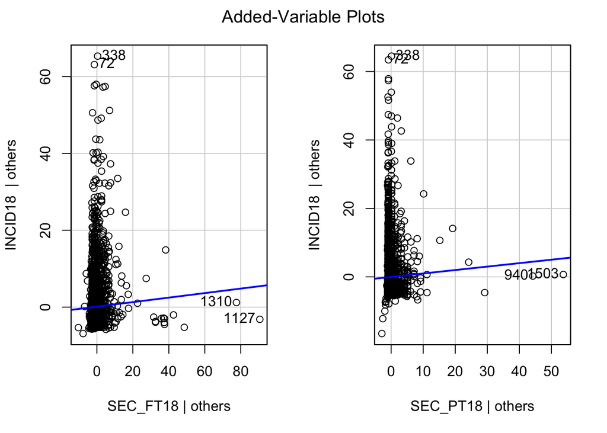

```
## Calls:
## 1: glm(formula = INCID18 ~ SEC_FT18 + SEC_PT18, family = "poisson", data =
##   data)
## 2: glm(formula = INCID18 ~ SEC_FT18 + SEC_PT18, family = "poisson", data =
##   data, subset = -c(1503, 1127))
##
##              Model 1  Model 2
## (Intercept)  3.27488  3.25568
## SE           0.00387  0.00398
##
## SEC_FT18    0.025589 0.032616
## SE          0.000428 0.000475
##
## SEC_PT18     0.01731  0.02612
## SE           0.00120  0.00153
##
```

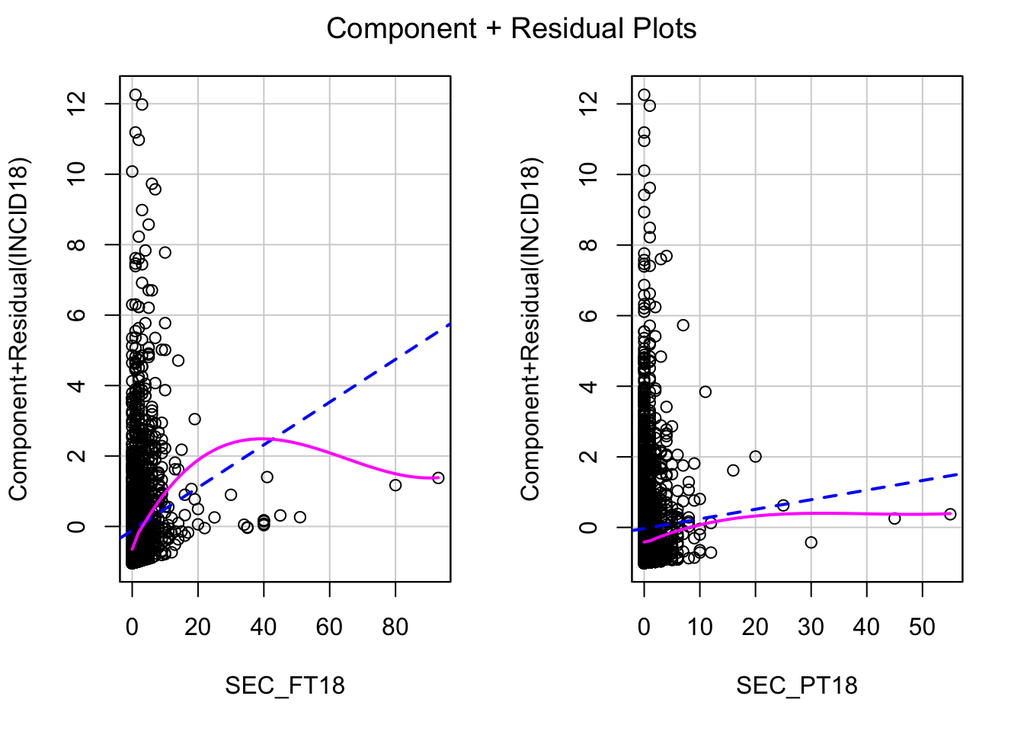

For `INCID18`, I carefully looked at the residuals plot and removed any influential data points (1127th, 1503th) to ensure that our results were as accurate as possible. However, according to the comparison of the coefficients, the standard errors are slightly larger than the original model. Hence, it doesn’t make any difference to remove the outliers or influential points.

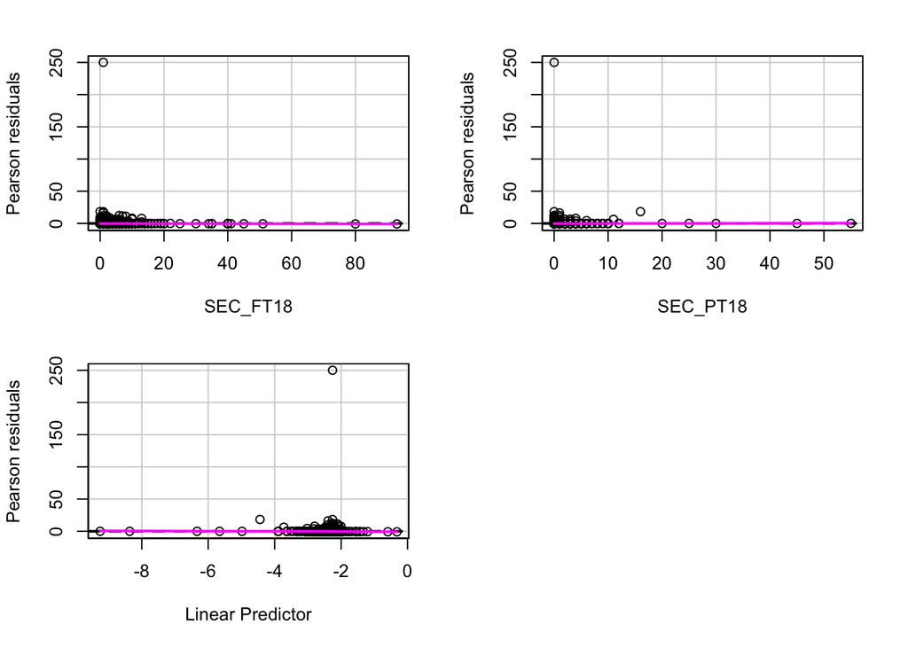

```
##          Test stat Pr(>|Test stat|)
## SEC_FT18   53.8312        2.185e-13 ***
## SEC_PT18    2.6084           0.1063
## ---
## Signif. codes:  0 '***' 0.001 '**' 0.01 '*' 0.05 '.' 0.1 ' ' 1
```

```
##       rstudent unadjusted p-value Bonferroni p
## 735  30.761886        8.4806e-208  2.3423e-204
## 209   6.079231         1.2076e-09   3.3354e-06
## 2528  5.505722         3.6766e-08   1.0155e-04
## 440   4.655585         3.2306e-06   8.9230e-03
## 919   4.628906         3.6760e-06   1.0153e-02
## 2577  4.610975         4.0078e-06   1.1070e-02
## 623   4.523824         6.0732e-06   1.6774e-02
## 1455  4.523824         6.0732e-06   1.6774e-02
## 501   4.506904         6.5781e-06   1.8169e-02
## 1328  4.475178         7.6348e-06   2.1087e-02
```

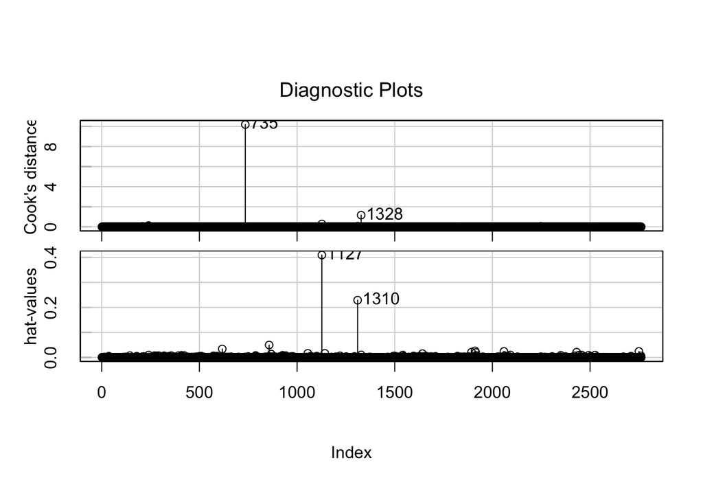

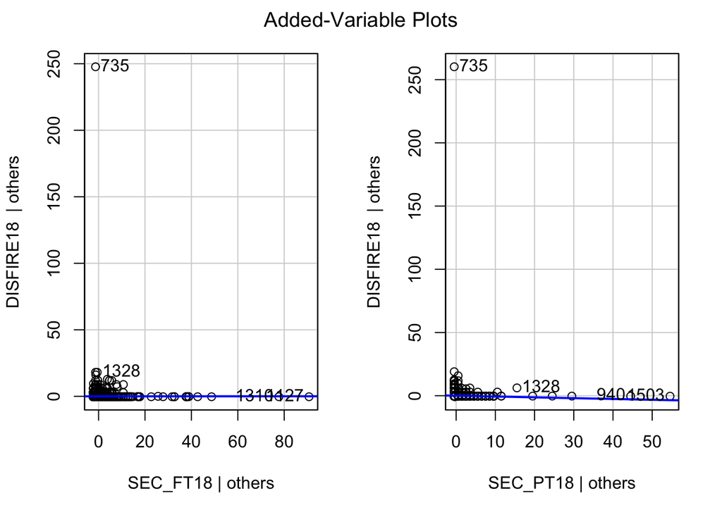

```
## Calls:
## 1: glm(formula = DISFIRE18 ~ SEC_FT18 + SEC_PT18, family = "poisson", data =
##    data)
## 2: glm(formula = DISFIRE18 ~ SEC_FT18 + SEC_PT18, family = "poisson", data =
##    data, subset = -c(1127, 1310, 735, 1328))
##
##             Model 1 Model 2
## (Intercept) -2.2781 -2.7215
## SE           0.0701  0.0851
##
## SEC_FT18    0.02105 0.05047
## SE          0.00825 0.01022
##
## SEC_PT18    -0.1352 -0.1004
## SE           0.0599  0.0645
##
```

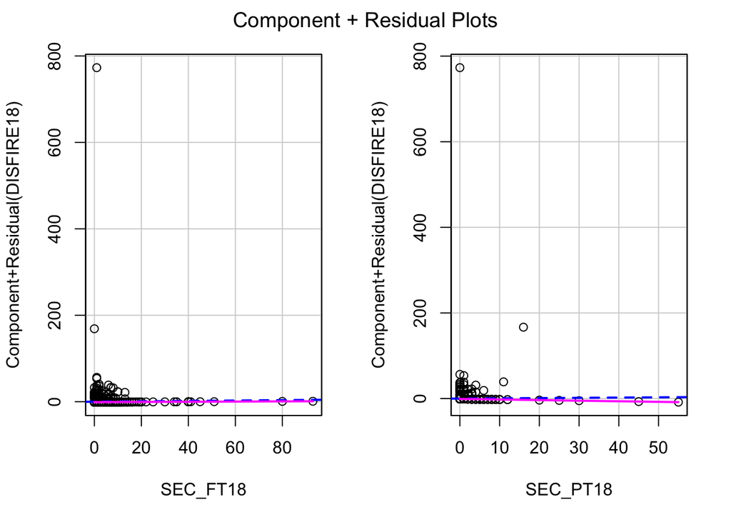

For `DISFIRE18`, I also carefully looked at the residuals plot and removed any influential data points (735th, 1328th, 1127th, 1310th) to ensure that our results were as accurate as possible. However, according to the comparison of the coefficients, the standard errors are slightly larger than the original model. Hence, I will retain our original model for further investigation.

Hence our final models are:

```
## Call: glm(formula = INCID18 ~ SEC_FT18 + SEC_PT18, family = "poisson", data =
##           data)
##
## Coefficients:
##             Estimate Std. Error z value Pr(>|z|)
## (Intercept) 3.274883   0.003869  846.49   <2e-16 ***
## SEC_FT18    0.025589   0.000428   59.79   <2e-16 ***
## SEC_PT18    0.017313   0.001199   14.44   <2e-16 ***
## ---
## Signif. codes:  0 '***' 0.001 '**' 0.01 '*' 0.05 '.' 0.1 ' ' 1
##
## (Dispersion parameter for poisson family taken to be 1)
##
##     Null deviance: 104912  on 2761  degrees of freedom
## Residual deviance: 102412  on 2759  degrees of freedom
##
##    logLik        df       AIC       BIC
## -56980.36         3 113966.71 113984.48
##
## Number of Fisher Scoring iterations: 7
##
## Exponentiated Coefficients and Confidence Bounds
##              Estimate     2.5 %    97.5 %
## (Intercept) 26.440132 26.240220 26.641195
## SEC_FT18     1.025919  1.025051  1.026772
## SEC_PT18     1.017464  1.015040  1.019823
```

```
## Call: glm(formula = DISFIRE18 ~ SEC_FT18 + SEC_PT18, family = "poisson", data =
##           data)
##
## Coefficients:
##              Estimate Std. Error z value Pr(>|z|)
## (Intercept) -2.278080   0.070081 -32.506   <2e-16 ***
## SEC_FT18     0.021047   0.008246   2.552   0.0107 *
## SEC_PT18    -0.135213   0.059944  -2.256   0.0241 *
## ---
## Signif. codes:  0 '***' 0.001 '**' 0.01 '*' 0.05 '.' 0.1 ' ' 1
##
## (Dispersion parameter for poisson family taken to be 1)
##
##     Null deviance: 2192.8  on 2761  degrees of freedom
## Residual deviance: 2181.5  on 2759  degrees of freedom
##
##   logLik       df      AIC      BIC
## -1235.73        3  2477.46  2495.23
##
## Number of Fisher Scoring iterations: 7
##
## Exponentiated Coefficients and Confidence Bounds
##              Estimate      2.5 %    97.5 %
## (Intercept) 0.1024807 0.08913294 0.1173177
## SEC_FT18    1.0212698 1.00172863 1.0353506
## SEC_PT18    0.8735301 0.76926362 0.9711766
```

3. To what extent do these effects differ in urban schools versus non-urban schools?

From the `code_book`, we know that when `FR_URBAN = 1`, the school are in urban areas.

```
## Call: glm(formula = INCID18 ~ SEC_FT18 * URBAN + SEC_PT18 * URBAN, family =
##           "poisson", data = data)
##
## Coefficients:
##                  Estimate Std. Error z value Pr(>|z|)
## (Intercept)     3.1658884  0.0047142 671.571  < 2e-16 ***
## SEC_FT18        0.0299897  0.0005547  54.065  < 2e-16 ***
## URBAN           0.3688636  0.0083947  43.940  < 2e-16 ***
## SEC_PT18        0.0199506  0.0012389  16.104  < 2e-16 ***
## SEC_FT18:URBAN -0.0128247  0.0009483 -13.523  < 2e-16 ***
## URBAN:SEC_PT18 -0.0144237  0.0037050  -3.893  9.9e-05 ***
## ---
## Signif. codes:  0 '***' 0.001 '**' 0.01 '*' 0.05 '.' 0.1 ' ' 1
##
## (Dispersion parameter for poisson family taken to be 1)
##
##     Null deviance: 104912  on 2761  degrees of freedom
## Residual deviance: 100456  on 2756  degrees of freedom
##
##   logLik       df      AIC      BIC
## -56002.6        6 112017.2 112052.8
##
## Number of Fisher Scoring iterations: 6
##
## Exponentiated Coefficients and Confidence Bounds
##                  Estimate      2.5 %     97.5 %
## (Intercept)    23.7097996 23.4914729 23.9296167
## SEC_FT18        1.0304440  1.0293127  1.0315544
## URBAN           1.4460904  1.4224784  1.4700664
## SEC_PT18        1.0201510  1.0176352  1.0225904
## SEC_FT18:URBAN  0.9872572  0.9854080  0.9890798
## URBAN:SEC_PT18  0.9856798  0.9784413  0.9927575
```

```
## Call: glm(formula = DISFIRE18 ~ SEC_FT18 * URBAN + SEC_PT18 * URBAN, family =
##           "poisson", data = data)
##
## Coefficients:
##                 Estimate Std. Error z value Pr(>|z|)
## (Intercept)    -2.121099   0.079216 -26.776  < 2e-16 ***
## SEC_FT18        0.022032   0.010503   2.098 0.035933 *
## URBAN          -0.506786   0.164350  -3.084 0.002045 **
## SEC_PT18       -0.333440   0.090901  -3.668 0.000244 ***
## SEC_FT18:URBAN  0.001418   0.016698   0.085 0.932305
## URBAN:SEC_PT18  0.395507   0.100372   3.940 8.13e-05 ***
## ---
## Signif. codes:  0 '***' 0.001 '**' 0.01 '*' 0.05 '.' 0.1 ' ' 1
##
## (Dispersion parameter for poisson family taken to be 1)
##
##     Null deviance: 2192.8  on 2761  degrees of freedom
## Residual deviance: 2162.8  on 2756  degrees of freedom
##
##   logLik       df      AIC      BIC
## -1226.37        6  2464.74  2500.28
##
## Number of Fisher Scoring iterations: 10
##
## Exponentiated Coefficients and Confidence Bounds
##                 Estimate     2.5 %    97.5 %
## (Intercept)    0.1198998 0.1023405 0.1396244
## SEC_FT18       1.0222769 0.9971832 1.0401007
## URBAN          0.6024289 0.4330468 0.8259045
## SEC_PT18       0.7164549 0.5915491 0.8446059
## SEC_FT18:URBAN 1.0014194 0.9619536 1.0339056
## URBAN:SEC_PT18 1.4851369 1.2224069 1.8231100
```

4. Do your analyses suggest that policymakers are correct that security guards reduce crime and gun violence? If so, explain why. If not, conduct additional analyses (using regression) that allow you to evaluate their claim and interpret your results.

```
##
## Call:
## glm(formula = DISFIRE18 ~ SEC_FT18 + SEC_PT18, family = "poisson",
##     data = data)
##
## Deviance Residuals:
##     Min       1Q   Median       3Q      Max
## -1.2047  -0.4575  -0.4527  -0.4231  30.2614
##
## Coefficients:
##              Estimate Std. Error z value Pr(>|z|)
## (Intercept) -2.278080   0.070081 -32.506   <2e-16 ***
## SEC_FT18     0.021047   0.008246   2.552   0.0107 *
## SEC_PT18    -0.135213   0.059944  -2.256   0.0241 *
## ---
## Signif. codes:  0 '***' 0.001 '**' 0.01 '*' 0.05 '.' 0.1 ' ' 1
##
## (Dispersion parameter for poisson family taken to be 1)
##
##     Null deviance: 2192.8  on 2761  degrees of freedom
## Residual deviance: 2181.5  on 2759  degrees of freedom
## AIC: 2477.5
##
## Number of Fisher Scoring iterations: 7
```

```
##
## Call:
## glm(formula = INCID18 ~ SEC_FT18 + SEC_PT18, family = "poisson",
##     data = data)
##
## Deviance Residuals:
##     Min       1Q   Median       3Q      Max
## -21.854   -5.456   -2.660    1.269   35.095
##
## Coefficients:
##             Estimate Std. Error z value Pr(>|z|)
## (Intercept) 3.274883   0.003869  846.49   <2e-16 ***
## SEC_FT18    0.025589   0.000428   59.79   <2e-16 ***
## SEC_PT18    0.017313   0.001199   14.44   <2e-16 ***
## ---
## Signif. codes:  0 '***' 0.001 '**' 0.01 '*' 0.05 '.' 0.1 ' ' 1
##
## (Dispersion parameter for poisson family taken to be 1)
##
##     Null deviance: 104912  on 2761  degrees of freedom
## Residual deviance: 102412  on 2759  degrees of freedom
## AIC: 113967
##
## Number of Fisher Scoring iterations: 7
```

The regression model **poisson_model_IN** applied to `INCID18` indicates that policymakers’ claim that security guards reduce crime might be inaccurate. The results indicate that the coefficients for both SEC_FT18 and SEC_PT18 are positively significant, meaning that having more security guards in schools is associated with a higher incidence of crime and gun violence. It doesn’t make any sense to me. But after careful consideration, one possible explanation for why an increase in security guards might be associated with an increase in crime, including gun violence, is that the presence of security guards may create a perception of safety and security, which in turn may encourage people to engage in riskier behavior or to commit crimes that they may not have otherwise. In addition, it is possible that the increase in crime could be due to other factors not accounted for in the analysis, and the relationship between security guards and crime may be more complex than a simple causal relationship.

Based on the given statement, it appears that there is no clear causal relationship between the variables being studied. This could be due to the fact that the variables are simultaneously observed, meaning that their values are all observed at the same time and there is no clear indication of which variable might be causing changes in the other variable. Therefore, it may not be possible to determine which factor is inducing the other factor.

The **poisson_model_DI** shows that an increase in the number of full-time security guards is linked to an increase in the total use of firearm or explosive, while an increase in the number of part-time security guards is associated with a decrease in the total use of firearm or explosive. The negative coefficient for part-time security guards supports the notion that they can reduce gun violence, but the positive coefficient for full-time security guards contradicts it. However, one possible explanation for why an increase in security guards might be associated with an increase in crime, including gun violence, is that the presence of security guards may create a perception of safety and security, which in turn may encourage people to engage in riskier behavior or to commit crimes that they may not have otherwise. In addition, it is possible that the increase in crime could be due to other factors not accounted for in the analysis, and the relationship between security guards and crime may be more complex than a simple causal relationship.

In summary, additional investigation and examination are required to completely understand the correlation between security guards and the frequency of criminal activity and firearm-related violence in educational institutions.

# Part II. Predicting Crime

Other researchers and policymakers would like to develop a model to predict crime (`INCID18`) based upon observable school characteristics. Their idea is that they could first predict schools that have a lot of crime and then put in place interventions that could reduce such crime.

For this part, perform the following tasks.

1. For your first model, use variables `C0532`, `C0534`, `C0536`, `C0538`, `C0560`, `C0562`, `C0568`, `FR_LVEL`, `FR_URBAN`, and `FR_SIZE` as predictor variables. Be sure to pay attention to non-linearities and interactions. (In addition to Appendix B, you can find more detailed explanation for the variables `C0532` to `C0568` on pages 80-81 of the code book, and the three variables `FR_LVEL`, `FR_URBAN`, and `FR_SIZE` on page 172). How well does this model perform?

```
##          R2     RMSE      MAE
## 1 0.2132625 42.61726 24.09856
```

```
## [1] 1.605724
```

The RMSE and the MAE are measured in the same scale as the outcome variable. Dividing the RMSE by the average value of the outcome variable will give you the prediction error rate, which should be as small as possible, but in our output, the value is 1.605724, large eought, hence the model performs badly.

2. Create a new model that includes only those covariates that were statistically significant in (1), further refining this until all covariates in this model are statistically significant. How well does this model perform relative to Model (1)?

```
## Call: glm(formula = INCID18 ~ C0532 + C0534 + C0536 + C0538 + C0560 + C0562 +
##           C0568 + FR_LVEL + FR_URBAN + FR_SIZE, family = poisson, data = data[, 1:202])
##
## Coefficients:
##               Estimate Std. Error z value Pr(>|z|)
## (Intercept)  1.9816584  0.0576110  34.397   <2e-16 ***
## C0532        0.0063960  0.0002128  30.053   <2e-16 ***
## C0534       -0.0039190  0.0002103 -18.638   <2e-16 ***
## C0536       -0.0039174  0.0002128 -18.410   <2e-16 ***
## C0538        0.0542982  0.0017400  31.206   <2e-16 ***
## C0560       -0.0728414  0.0057688 -12.627   <2e-16 ***
## C0562       -0.1680550  0.0076640 -21.928   <2e-16 ***
## C0568        0.0004917  0.0005511   0.892    0.372
## FR_LVEL      0.1607717  0.0051371  31.296   <2e-16 ***
## FR_URBAN    -0.0822063  0.0039675 -20.720   <2e-16 ***
## FR_SIZE      0.5770237  0.0051076 112.974   <2e-16 ***
## ---
## Signif. codes:  0 '***' 0.001 '**' 0.01 '*' 0.05 '.' 0.1 ' ' 1
##
## (Dispersion parameter for poisson family taken to be 1)
##
##     Null deviance: 104912  on 2761  degrees of freedom
## Residual deviance:  72079  on 2751  degrees of freedom
##
##    logLik        df       AIC       BIC
## -41814.11        11  83650.22  83715.38
##
## Number of Fisher Scoring iterations: 6
##
## Exponentiated Coefficients and Confidence Bounds
##              Estimate     2.5 %    97.5 %
## (Intercept) 7.2547643 6.4757182 8.1164876
## C0532       1.0064165 1.0059961 1.0068357
## C0534       0.9960887 0.9956785 0.9964995
## C0536       0.9960902 0.9956750 0.9965059
## C0538       1.0557994 1.0522042 1.0594055
## C0560       0.9297483 0.9192871 0.9403120
## C0562       0.8453073 0.8327140 0.8581103
## C0568       1.0004918 0.9994207 1.0015823
## FR_LVEL     1.1744169 1.1626506 1.1863005
## FR_URBAN    0.9210819 0.9139433 0.9282685
## FR_SIZE     1.7807305 1.7630185 1.7986724
```

```
## Call: glm(formula = INCID18 ~ C0532 + C0534 + C0536 + C0538 + C0560 + C0562 +
##           FR_LVEL + FR_URBAN + FR_SIZE, family = poisson, data = data)
##
## Coefficients:
##               Estimate Std. Error z value Pr(>|z|)
## (Intercept)  2.0260891  0.0289318   70.03   <2e-16 ***
## C0532        0.0063717  0.0002111   30.18   <2e-16 ***
## C0534       -0.0039129  0.0002102  -18.62   <2e-16 ***
## C0536       -0.0039120  0.0002127  -18.39   <2e-16 ***
## C0538        0.0543359  0.0017394   31.24   <2e-16 ***
## C0560       -0.0726000  0.0057621  -12.60   <2e-16 ***
## C0562       -0.1680782  0.0076636  -21.93   <2e-16 ***
## FR_LVEL      0.1601015  0.0050816   31.51   <2e-16 ***
## FR_URBAN    -0.0820362  0.0039628  -20.70   <2e-16 ***
## FR_SIZE      0.5774708  0.0050829  113.61   <2e-16 ***
## ---
## Signif. codes:  0 '***' 0.001 '**' 0.01 '*' 0.05 '.' 0.1 ' ' 1
##
## (Dispersion parameter for poisson family taken to be 1)
##
##     Null deviance: 104912  on 2761  degrees of freedom
## Residual deviance:  72080  on 2752  degrees of freedom
##
##    logLik        df       AIC       BIC
## -41814.51        10  83649.02  83708.26
##
## Number of Fisher Scoring iterations: 6
##
## Exponentiated Coefficients and Confidence Bounds
##              Estimate     2.5 %    97.5 %
## (Intercept) 7.5843664 7.1658494 8.0264089
## C0532       1.0063921 1.0059751 1.0068081
## C0534       0.9960947 0.9956847 0.9965053
## C0536       0.9960957 0.9956807 0.9965111
## C0538       1.0558392 1.0522452 1.0594440
## C0560       0.9299728 0.9195212 0.9405268
## C0562       0.8452877 0.8326954 0.8580897
## FR_LVEL     1.1736300 1.1619976 1.1853759
## FR_URBAN    0.9212386 0.9141073 0.9284177
## FR_SIZE     1.7815268 1.7638929 1.7993900
```

```
##          R2     RMSE      MAE
## 1 0.2132606 42.61734 24.09885
```

```
## [1] 1.605727
```

From the output, the only covariate that is not statistically significant is `C0568. But this model has a slightly larger RMSE than the previous one, which indicates the model performance hasn’t improved too much.

3. Develop and implement an approach to build the best model possible that predicts the total number of crimes (incidents, `INCID18`). (In addition to the variables mentioned in the previous problem, you may consider other variables, but be sure to explain your thinking.)

   What is your final model and why do you think it is the best? Be sure to clearly explain your approach in language a non-statistician could understand. ·

To approach this question, firstly, I will retain the significant variables in the previous question and next review the code-book to select the variables that make substantial sense to me.

`C0386` denotes **How often student verbal abuse of teachers** `C0376` denotes **How often student bullying** `SVPOL18` denotes **Total number of serious violent incidents reported to police** `OUTSUS18` denotes **Total out-of-school suspensions > 5 days but < the remainder of school for specified offenses** `C0294` denotes **Efforts limited by inadequate funds**

In addition to the significant variables, I will combine the variables I select to conduct a Stepwise variables selection.

```
##
## Call:
## glm(formula = INCID18 ~ FR_SIZE + OUTSUS18 + C0376 + C0386 +
##     SVPOL18 + C0536 + C0562 + C0538 + C0532 + FR_URBAN + FR_LVEL +
##     C0534 + C0294 + C0560, family = poisson, data = data)
##
## Deviance Residuals:
##     Min       1Q   Median       3Q      Max
## -22.361   -3.696   -1.705    1.060   36.282
##
## Coefficients:
##               Estimate Std. Error z value Pr(>|z|)
## (Intercept)  3.5598500  0.0389407  91.417  < 2e-16 ***
## FR_SIZE      0.4414353  0.0052702  83.760  < 2e-16 ***
## OUTSUS18     0.0097347  0.0001597  60.940  < 2e-16 ***
## C0376       -0.1718947  0.0036598 -46.968  < 2e-16 ***
## C0386       -0.1794021  0.0055446 -32.356  < 2e-16 ***
## SVPOL18      0.0552037  0.0015142  36.458  < 2e-16 ***
## C0536       -0.0030211  0.0002108 -14.333  < 2e-16 ***
## C0562       -0.0914408  0.0076064 -12.022  < 2e-16 ***
## C0538        0.0453747  0.0018012  25.191  < 2e-16 ***
## C0532        0.0026849  0.0002191  12.255  < 2e-16 ***
## FR_URBAN    -0.0711343  0.0039605 -17.961  < 2e-16 ***
## FR_LVEL      0.0927637  0.0054601  16.989  < 2e-16 ***
## C0534       -0.0021318  0.0002100 -10.154  < 2e-16 ***
## C0294       -0.0364578  0.0045248  -8.057 7.80e-16 ***
## C0560       -0.0318394  0.0055467  -5.740 9.45e-09 ***
## ---
## Signif. codes:  0 '***' 0.001 '**' 0.01 '*' 0.05 '.' 0.1 ' ' 1
##
## (Dispersion parameter for poisson family taken to be 1)
##
##     Null deviance: 104912  on 2761  degrees of freedom
## Residual deviance:  58771  on 2747  degrees of freedom
## AIC: 70350
##
## Number of Fisher Scoring iterations: 5
```

In order to measure the performance of the final model, I compute the RMSE from the cross-validation methods.

```
##          R2     RMSE      MAE
## 1 0.3504218 42.56601 24.10404
```

```
## [1] 1.603793
```

To summarize, our ultimate model displays superior performance compared to the preceding two models. Although the improvement from the original models is not substantial, the final model exhibits the lowest RMSE, highest coefficient of determination, and lowest AIC.

4. Does your final model do a good job in predicting crime? Explain to a policymaker if and how they should properly use this model.